# Loan Data from Prosper: Communicate Findings

## by Marc Campmany

## Investigation Overview

> In this project the main goal has been to analyze the features related mainly to the Borrower's APR (annual interest rate charged). The variables studied have been the Original Loan Amount, Borrower's Prosper Rating, Loan Term, Borrower's Income Range, Employment Status, Occupation and aim of the loan.

## Dataset Overview

> The original data set contains 113,937 loans with 81 variables on each loan, including loan amount, borrower rate (or interest rate), current loan status, borrower income, and many others. After cleaning operations, the dataset studied contains 83.968 unique loans with 15 related features.

## Distribution of loans listed per year and month

> 2013 was the year where more loans were requested. And normally the winter months have higher nº of loans than summer periods.

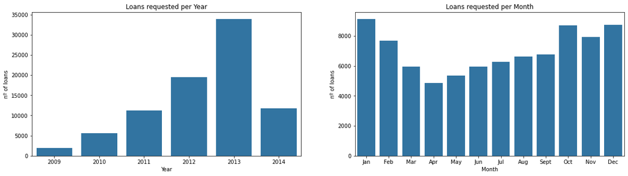

## Distribution of Borrower APRs

[figure not shown]

## Distribution of Borrower's Income Ranges

> Regardings the borrower's income we can see that the majority of Loans have been requested by 25k-75k incomes.

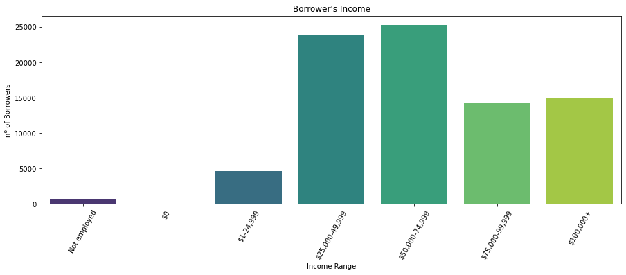

## Distribution of Debt to Income Ratio

> Distribution has unimodal shape peaking aroung 0.18 with a large peak around 0.25. This indicates most people have 1:4 ratio of debt to Income which would be a correct proportion.

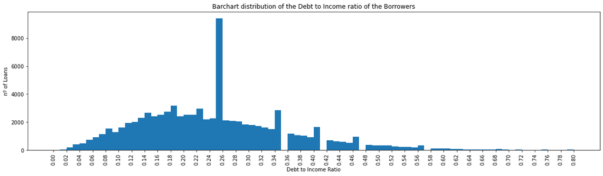

## Bivariate exploration: Borrower APR and Loan Amount vs categorical variables (Term, Rating, Employment, Income Range)

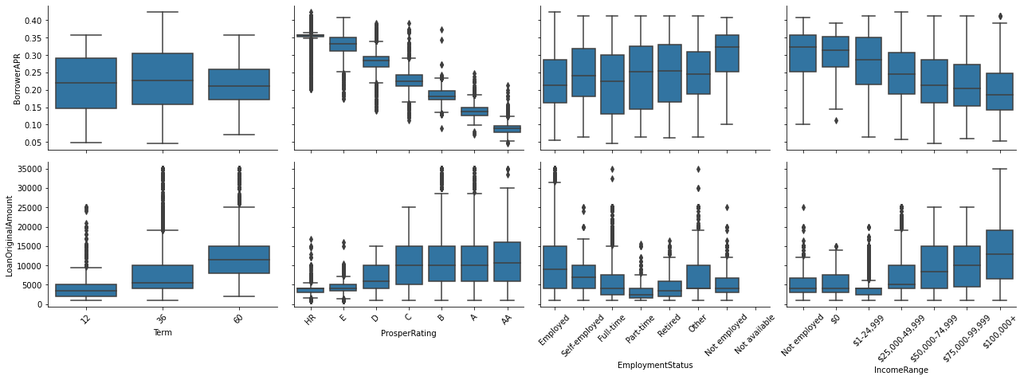

## Borrower APR vs Loan Amount

> We can see the negative correlation between the Borrowers interest rate and the amount of the Loan requested. As the amount is higher, the interests decrease.

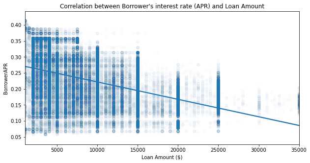

## Rating Effect on relationship between APR and Loan Amount

> Following with the analysis of the Borrower's APR vs the Loan Amount where we found a negative correlation, adding in the Prosper Rating confirms that this is a powerful combination given that the higher the rating the lower the interest and each of the categories is clearly plotted.

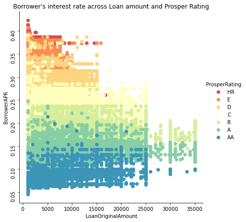

> We can see that the relationship BorrowerAPR vs Loan Amount goes from negative on ratings HR- B to slighly positive on ratings A and AA.

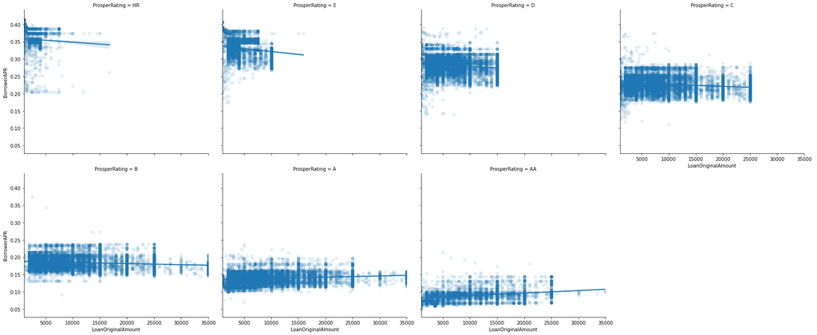

## Loan Amount vs Rating vs Term

> The higher loans equaled higher Terms. Now, it can also be confirmed that this pattern is extensible to all the Prosper Ratings.

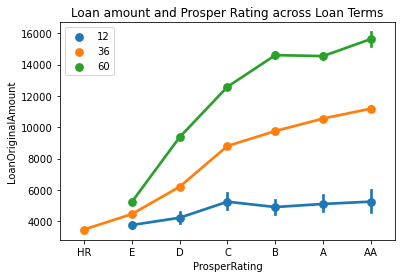

## Borrower APR vs Rating vs Term

> We can see that the better the rating the less interest rate. And adding in the Loan Terms we can see that as the Loan Rating gets better, the pattern is that the Terms increase. This is probably be due to the increase of the Loan Amount.

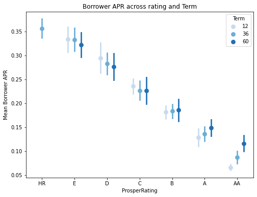

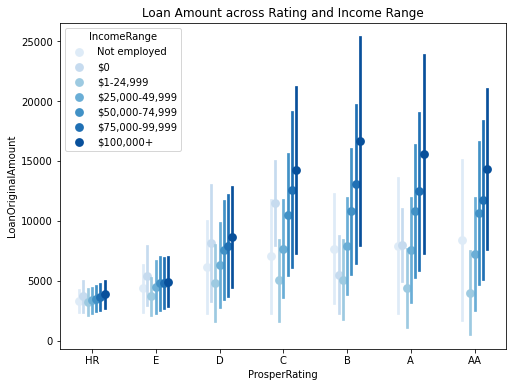

## Conclusions

- Extended the borrower APR vs loan amount by adding in the Prosper rating. The multivariate exploration showed that the relationship between borrower APR and loan amount goes from negative on ratings HR-B to slighly positive relationship on ratings A and AA.
- We can also see that the better the Prosper Rating the less Interest Rate is charged. And adding the Loan Terms, we can see that as the Loan Rating gets better, the pattern is that the Terms increase. This is probably also due to the increase of the Loan Amount.